# Lab Seven: Recurrent Network Architectures

### By Xiangying Chang, Fang Qi, Rui Lin, Shimeng Yuan

## Business Understanding

This dataset consists of a few million Amazon customer reviews (input text) and star ratings (output labels) for learning how to train fastText for sentiment analysis. In this case, the classes are label1 and label2. Label 1 means 1 and 2 star reviews and label 2 means 4 and 5 star reviews.

Nowadays, shopping online is a common way in the United States. And the competition in the this area is very fierce. The United States is one of the largest online markets around the world. In the overall US online market, Amazon is an important component. People are always motivated by the cheaper price, free shipping and convenience to shop on Amazon. And the real-time updated reviews is one of the most important way to help the online business to develop better by learning form the market through the reviews.

In this lab, we used Recurrent Neural Network (RNN) architectures to do the prediction task. Through the Recurrent Neural Network architectures and sentiment analysis of the reviews on Amazon, we are able to help buyers and sellers to identify the most significant words leading to the star of the reviews. From the prediction result, the sellers could have an idea what kind of reviews are beneficial to their products. The buyers could filter the reviews to choose the most suitable goods.

Finally, it could also be generalized by other similar companies to predict the results to better improve their goods and services, like Alibaba, Groupon and so on.

Dataset Source: https://www.kaggle.com/bittlingmayer/amazonreviews

# 1. Preparation

## 1.1 Data Preparation

Our task is to predict the labels among different reviews. Due to the large dataset, we first chose the first 10000 datasets and removed all the punctuations digits and stopwords. And then we converted words to indexes using tokenizer. Here we used tokenizer.fit_on_texts as our method. Finally we split our data in stratified k-fold method.

```python
import pandas as pd
import numpy as np
import bz2
import os
import re
print(os.listdir("../input"))
```

```
['amazonreviews', 'glove6b100dtxt']
```

```python
train = bz2.BZ2File('../input/amazonreviews/train.ft.txt.bz2','r')
lines = train.readlines()
```

To fast read text file, We try to use a for loop.The code we used in the following cell are from reference https://www.kaggle.com/ayanmaity/ml-assignment-4

```python
# the follow code are from: https://www.kaggle.com/ayanmaity/ml-assignment-4
doclist = []
def getdoclist(docs,splitStr='__label__'):
    for i in range(len(docs)):
        line = str(lines[i])
        splitText = line.split(splitStr)
        secHalf = splitText[1]
        text = secHalf[2:len(secHalf)-1].lower()
        text = re.sub('\d','0', text)
        sentiment = secHalf[0]
        doclist.append([text,sentiment])
    return doclist
```

```python
#choose first 10000 reviews
doclist = getdoclist(lines[:10000],splitStr='__label__')
```

```python
import nltk
import ssl
try:
    _create_unverified_https_context = ssl._create_unverified_context
except AttributeError:
    pass
else:
    ssl._create_default_https_context = _create_unverified_https_context

nltk.download('stopwords')
nltk.download('punkt')
```

```
True
```

In order to better predict the results, we removed punctuations and digits.

```python
import string

remove_punctuation = str.maketrans(string.punctuation, ' '*len(string.punctuation))
for i in range(len(doclist)):
    doclist[i][0] = doclist[i][0].translate(remove_punctuation)

remove_digit = str.maketrans('', '', string.digits)
for i in range(len(doclist)):
    doclist[i][0] = doclist[i][0].translate(remove_digit)
```

```python
doclist[0:2]
```

```
[['stuning even for the non gamer  this sound track was beautiful  it paints the senery in your mind so well i would recomend it even to people who hate vid  game music  i have played the game chrono cross but out of all of the games i have ever played it has the best music  it backs away from crude…
  '2'],
 ['the best soundtrack ever to anything   i m reading a lot of reviews saying that this is the best  game soundtrack  and i figured that i d write a review to disagree a bit  this in my opinino is yasunori mitsuda s ultimate masterpiece  the music is timeless and i m been listening to it for years n…
  '2']]
```

Remove useless stopwords like "the" and other mood word.

```python
from nltk.corpus import stopwords
stop_words = set(stopwords.words('english'))
```

```python
for i in range(len(doclist)):
    doclist[i][0] = ' '.join([word for word in doclist[i][0].split() if word not in stop_words])
```

```python
doclist[0:2]
```

```
[['stuning even non gamer sound track beautiful paints senery mind well would recomend even people hate vid game music played game chrono cross games ever played best music backs away crude keyboarding takes fresher step grate guitars soulful orchestras would impress anyone cares listen n',
  '2'],
 ['best soundtrack ever anything reading lot reviews saying best game soundtrack figured write review disagree bit opinino yasunori mitsuda ultimate masterpiece music timeless listening years beauty simply refuses fade price tag pretty staggering must say going buy cd much money one feel would worth…
  '2']]
```

Convert words to indexes using tokenizer

```python
train_sentences = [line[0] for line in doclist]
```

```python
from keras.preprocessing import text, sequence

tokenizer = text.Tokenizer(num_words=20000)
tokenizer.fit_on_texts(train_sentences)
tokenized_train = tokenizer.texts_to_sequences(train_sentences)
```

```python
X = sequence.pad_sequences(tokenized_train, maxlen=50)
X[0]
```

```
array([    0,     0,     0,     0,     0, 16214,    16,   487,  8258,
         103,   348,   225,  5933, 16215,   262,    13,     9,  1608,
          16,    35,   591, 11930,    58,    42,   382,    58,  7259,
        1581,   488,    30,   382,    21,    42,  9682,   144,  2629,
       16216,   283, 11931,   953, 16217,  3189,  5934, 16218,     9,
        3190,    79,  2229,   250,     1], dtype=int32)
```

```python
y = np.array([line[1] for line in doclist])
y[0:2]
```

```
array(['2', '2'], dtype='<U1')
```

```python
train_df = pd.DataFrame(list(zip(X,y)),columns=['text','sentiment'])
train_df.head()
```

|  | text | sentiment |
| --- | --- | --- |
| 0 | [0, 0, 0, 0, 0, 16214, 16, 487, 8258, 103, 348... | 2 |
| 1 | [0, 0, 0, 21, 739, 30, 167, 43, 78, 137, 896, ... | 2 |
| 2 | [484, 2721, 1078, 648, 2913, 57, 1280, 1365, 3... | 2 |
| 3 | [1997, 7261, 324, 16225, 9684, 5018, 1205, 53,... | 2 |
| 4 | [0, 0, 0, 422, 1249, 3481, 1680, 1232, 382, 58... | 2 |

```python
train_df['sentiment'][train_df['sentiment']=='1'] = 0
train_df['sentiment'][train_df['sentiment']=='2'] = 1
train_df.head()
```

|  | text | sentiment |
| --- | --- | --- |
| 0 | [0, 0, 0, 0, 0, 16214, 16, 487, 8258, 103, 348... | 1 |
| 1 | [0, 0, 0, 21, 739, 30, 167, 43, 78, 137, 896, ... | 1 |
| 2 | [484, 2721, 1078, 648, 2913, 57, 1280, 1365, 3... | 1 |
| 3 | [1997, 7261, 324, 16225, 9684, 5018, 1205, 53,... | 1 |
| 4 | [0, 0, 0, 422, 1249, 3481, 1680, 1232, 382, 58... | 1 |

```python
#check to see the distribution in 2 classes
train_df['sentiment'].describe()
```

```
count     10000
unique        2
top           0
freq       5097
Name: sentiment, dtype: int64
```

```python
y = np.array(train_df['sentiment'].tolist())
from sklearn.utils.multiclass import type_of_target
print(type_of_target(y),y.shape)
```

```
binary (10000,)
```

## 1.2 Evaluation Metrics

There are four common evaluation metrics: Accuracy, Precision, Recall, F1-score. In order to choose the appropriate metric, we need to compare these different metrics based on our data. For each word in the reviews, there are 4 cases:

1. True Positive - Prediction is label1 and class is also label1.
2. False Positive - Prediction is label1 but class is label2.
3. False Negative - Prediction is label2 but class is label1.
4. True Negative - Prediction is label2 and class is also label2. The reason why we mention these four conditions is they are related to four common evaluation metrics. Accuracy indicates how many proportions of our sample are correct, this includes both TP and TN, however we want to focus on TP because it is what we would like to use in practical applications. We hope people can recognize words from the reviews and get the right prediction result.

Next, considering Precision, Recall and F1-score together. Precision reflects the ability to identify type I error, Recall reflects the ability to identify type II error, they both focus on TP. F1-score is the combination of these two metrics and it finds a balance between Precision and Recall, so F1 score is better.

And for our business circumstances, we need to help people combine the reviews and stars together, because most people can't combine different reviews with corresponding stars, so we need to improve the accuracy, F1-score is also good to solve this problem. Therefore, we decide to select F1-score as our metric.

F1 scores has macro average and micro average methods.A macro-average will compute the metric independently for each class and then take the average (hence treating all classes equally), it counts the TP, FP, FN, and TN of each class, calculate their respective precisions and recalls, get the respective F1 values, and then take the average to get the macro-F1. Micro-average will aggregate the contributions of all classes to compute the average metric. In our case, it is equally distributed in two classes, so we chose the macro-average method.

## 1.3 Data Splitting

We are considering Stratified K-fold and stratified Shuffle splits as cross validation methods for our model. They both split the data into n_splits parts. However, there are some differences between them. For Stratified K-fold, the dataset is simply divided into k folds, and training proportion in each iteration is k-1/k. For stratified Shuffle splits, it randomly shuffles the dataset each time before splitting and splits n_splits time, so test sets may be overlapped, and it is also possible that some data would never appear in the train set or test set.

In our dataset, we want to predict the star level based on each word in the reviews. Since in stratified Shuffle splits, the same samples could be selected many times in test data, so it will result in some words never showed in test data. This makes the result become less convinced and less accurate. So we would like to use Stratified K-fold as our cross validation method.

# 2. Modeling

### We select f1_score as the evaluation metric, since Precision, Recall and F1 metrics have been removed from metrics.py, so we try to calculate f1_score by using code. The code we used in the following cell are all from reference https://stackoverflow.com/questions/43547402/how-to-calculate-f1-macro-in-keras

```python
# The code we used in the following cell are all from reference https://stackoverflow.com/questions/43547402/how-to-calculate-f1-macro-in-keras
from keras import backend as K

def f1_score(y_true, y_pred):
    def recall(y_true, y_pred):
        true_positives = K.sum(K.round(K.clip(y_true * y_pred, 0, 1)))
        possible_positives = K.sum(K.round(K.clip(y_true, 0, 1)))
        recall = true_positives / (possible_positives + K.epsilon())
        return recall

    def precision(y_true, y_pred):
        true_positives = K.sum(K.round(K.clip(y_true * y_pred, 0, 1)))
        predicted_positives = K.sum(K.round(K.clip(y_pred, 0, 1)))
        precision = true_positives / (predicted_positives + K.epsilon())
        return precision
    precision = precision(y_true, y_pred)
    recall = recall(y_true, y_pred)
    return 2*((precision*recall)/(precision+recall+K.epsilon()))
```

## 2.1 Investigate Different Recurrent Network Architectures

### 2.1.1 LSTM (Trained From Scratch)

```python
from sklearn.model_selection import StratifiedKFold
cv = StratifiedKFold(n_splits=5)
```

```python
from keras.models import Sequential, Input, Model
from keras.layers import Dense
from keras.layers import LSTM, GRU
from keras.layers.embeddings import Embedding

top_words = 10000
max_review_length = 50
NUM_CLASSES = 1
EMBED_SIZE = 50
i = 0
score1 = []
val_score1 = []

for train_index, test_index in cv.split(X,y):
    i = i + 1
    print('Fold:', i)
    X_train, X_test = X[train_index], X[test_index]
    y_train, y_test = y[train_index], y[test_index]
    print(X_train.shape, y_train.shape)
    input_holder = Input(shape=(X_train.shape[1], ))
    shared_embed = Embedding(top_words, # input dimension (max int of OHE)
                             EMBED_SIZE, # output dimension size
                             input_length=max_review_length)(input_holder)

    x = LSTM(50, dropout=0.2, recurrent_dropout=0.2)(shared_embed)
    x = Dense(NUM_CLASSES, activation='sigmoid')(x)
    lstm_rnn=Model(inputs=input_holder,outputs=x)
    lstm_rnn.compile(loss='binary_crossentropy',
                     optimizer='rmsprop',
                     metrics=[f1score])
    history1 = lstm_rnn.fit(X_train, y_train, epochs=10, batch_size=64, validation_data=(X_test, y_test))
    score = np.sum(history1.history['f1score'])/10
    val_score = np.sum(history1.history['val_f1score'])/10
    score1.append(score)
    val_score1.append(val_score)

print(lstm_rnn.summary())
```

```
Fold: 1
(7999, 50) (7999,)
Train on 7999 samples, validate on 2001 samples
Fold: 2
(7999, 50) (7999,)
Train on 7999 samples, validate on 2001 samples
Fold: 3
(8000, 50) (8000,)
Train on 8000 samples, validate on 2000 samples
Fold: 4
(8001, 50) (8001,)
Train on 8001 samples, validate on 1999 samples
Fold: 5
(8001, 50) (8001,)
Train on 8001 samples, validate on 1999 samples
_________________________________________________________________
Layer (type)                 Output Shape              Param #
=================================================================
input_10 (InputLayer)        (None, 50)                0
_________________________________________________________________
embedding_10 (Embedding)     (None, 50, 50)            500000
_________________________________________________________________
lstm_10 (LSTM)               (None, 50)                20200
_________________________________________________________________
dense_10 (Dense)             (None, 1)                 51
=================================================================
Total params: 520,251
Trainable params: 520,251
Non-trainable params: 0
_________________________________________________________________
None
```

```python
for score in score1:
    print(score)
lstm_rnn_score = np.mean(np.array(score1))
print("average f1score:", lstm_rnn_score)

for score in val_score1:
    print(score)
lstm_rnn_val_score = np.mean(np.array(val_score1))
print("average val_f1score:", lstm_rnn_val_score)
```

```
0.9198312909711314
0.9220165846600862
0.9143956912457943
0.9150226158978656
0.9089537171755205
average f1score: 0.9160439799900797
0.8198623203057638
0.7982015279875225
0.7421600710868835
0.7318281375330171
0.7965505709553911
average val_f1score: 0.7777205255737156
```

For LSTM (Trained From Scratch), we can get that the the average f1score is 0.916, and the average val_f1score is 0.7777, the average val_f1score is not that good, but it still acceptable since our dataset is text..

### 2.1.2 LSTM (Using the GloVe Pre-Trained Embedding)

```python
import keras

NUM_TOP_WORDS = None
MAX_ART_LEN = 50 # maximum and minimum number of words

word_index = tokenizer.word_index
NUM_TOP_WORDS = len(word_index) if NUM_TOP_WORDS==None else NUM_TOP_WORDS
top_words = min((len(word_index),NUM_TOP_WORDS))
print('Found %s unique tokens. Distilled to %d top words.' % (len(word_index),top_words))

X = sequence.pad_sequences(tokenized_train, maxlen=MAX_ART_LEN)

y_ohe = keras.utils.to_categorical(y)
print('Shape of data tensor:', X.shape)
print('Shape of label tensor:', y_ohe.shape)
print(np.max(X))
```

```
Found 30613 unique tokens. Distilled to 30613 top words.
Shape of data tensor: (10000, 50)
Shape of label tensor: (10000, 2)
19999
```

```python
%%time
EMBED_SIZE = 100
# the embed size should match the file you load glove from
embeddings_index = {}
f = open('../input/glove6b100dtxt/glove.6B.100d.txt')
# save key/array pairs of the embeddings
#  the key of the dictionary is the word, the array is the embedding
for line in f:
    values = line.split()
    word = values[0]
    coefs = np.asarray(values[1:], dtype='float32')
    embeddings_index[word] = coefs
f.close()

print('Found %s word vectors.' % len(embeddings_index))

# now fill in the matrix, using the ordering from the
#  keras word tokenizer from before
embedding_matrix = np.zeros((len(word_index) + 1, EMBED_SIZE))
for word, i in word_index.items():
    embedding_vector = embeddings_index.get(word)
    if embedding_vector is not None:
        # words not found in embedding index will be all-zeros.
        embedding_matrix[i] = embedding_vector

print(embedding_matrix.shape)
```

```
Found 400000 word vectors.
(30614, 100)
CPU times: user 10.1 s, sys: 296 ms, total: 10.4 s
Wall time: 10.4 s
```

```python
MAX_ART_LEN = 50

embedding_layer = Embedding(len(word_index) + 1,
                            EMBED_SIZE,
                            weights=[embedding_matrix],
                            input_length=MAX_ART_LEN,
                            trainable=False)
```

```python
NUM_CLASSES = 2
i = 0
score2 = []
val_score2 = []

for train_index, test_index in cv.split(X,y):
    i = i + 1
    print('Fold:', i)
    X_train, X_test = X[train_index], X[test_index]
    y_train, y_test = y[train_index], y[test_index]
    y_train_ohe = keras.utils.to_categorical(y_train)
    y_test_ohe = keras.utils.to_categorical(y_test)

    lstm_glove = Sequential()
    lstm_glove.add(embedding_layer)
    lstm_glove.add(LSTM(100, dropout=0.2, recurrent_dropout=0.2))
    lstm_glove.add(Dense(NUM_CLASSES, activation='sigmoid'))
    lstm_glove.compile(loss='categorical_crossentropy',
                       optimizer='rmsprop',
                       metrics=[f1score])
    history2 = lstm_glove.fit(X_train, y_train_ohe, validation_data=(X_test, y_test_ohe), epochs=10, batch_size=64)
    score = np.sum(history2.history['f1score'])/10
    val_score = np.sum(history2.history['val_f1score'])/10
    score2.append(score)
    val_score2.append(val_score)

print(lstm_glove.summary())
```

```
Fold: 1
Train on 7999 samples, validate on 2001 samples
Fold: 2
Train on 7999 samples, validate on 2001 samples
Fold: 3
Train on 8000 samples, validate on 2000 samples
Fold: 4
Train on 8001 samples, validate on 1999 samples
Fold: 5
Train on 8001 samples, validate on 1999 samples
_________________________________________________________________
Layer (type)                 Output Shape              Param #
=================================================================
embedding_11 (Embedding)     (None, 50, 100)           3061400
_________________________________________________________________
lstm_15 (LSTM)               (None, 100)               80400
_________________________________________________________________
dense_15 (Dense)             (None, 2)                 202
=================================================================
Total params: 3,142,002
Trainable params: 80,602
Non-trainable params: 3,061,400
_________________________________________________________________
None
```

```python
for score in score2:
    print(score)
lstm_glove_score = np.mean(np.array(score2))
print("average f1score:", lstm_glove_score)

for score in val_score2:
    print(score)
lstm_glove_val_score = np.mean(np.array(val_score2))
print("average val_f1score:", lstm_glove_val_score)
```

```
0.7419194582403116
0.6701048765000379
0.7078472091674805
0.6933444388828164
0.7603799751610655
average f1score: 0.7147191915903424
0.7736450635749421
0.6717506037823024
0.7126849989175795
0.6381319697534459
0.7571005675272682
average val_f1score: 0.7106626407111076
```

From the average score above, we can get that the average f1score of LSTM (Using the GloVe Pre-Trained Embedding) is 0.715, and the average val_f1score is 0.711. Both of them are lower than trained from scratch LSTM.

### 2.1.3 GRU (Trained From Scratch)

```python
top_words = 20000
max_review_length = 50
NUM_CLASSES = 1
EMBED_SIZE = 50
i = 0
score3 = []
val_score3 = []

for train_index, test_index in cv.split(X,y):
    i = i + 1
    print('Fold:', i)
    X_train, X_test = X[train_index], X[test_index]
    y_train, y_test = y[train_index], y[test_index]
    print(X_train.shape, y_train.shape)
    input_holder = Input(shape=(X_train.shape[1], ))
    shared_embed = Embedding(top_words, # input dimension (max int of OHE)
                             EMBED_SIZE, # output dimension size
                             input_length=max_review_length)(input_holder)

    x = GRU(50, dropout=0.2, recurrent_dropout=0.2)(shared_embed)
    x = Dense(NUM_CLASSES, activation='sigmoid')(x)
    gru_rnn=Model(inputs=input_holder,outputs=x)
    gru_rnn.compile(loss='binary_crossentropy',
                    optimizer='rmsprop',
                    metrics=[f1score])
    history3 = gru_rnn.fit(X_train, y_train, epochs=10, batch_size=64, validation_data=(X_test, y_test))
    score = np.sum(history3.history['f1score'])/10
    val_score = np.sum(history3.history['val_f1score'])/10
    score3.append(score)
    val_score3.append(val_score)

print(gru_rnn.summary())
```

```
Fold: 1
(7999, 50) (7999,)
Train on 7999 samples, validate on 2001 samples
Fold: 2
(7999, 50) (7999,)
Train on 7999 samples, validate on 2001 samples
Fold: 3
(8000, 50) (8000,)
Train on 8000 samples, validate on 2000 samples
Fold: 4
(8001, 50) (8001,)
Train on 8001 samples, validate on 1999 samples
Fold: 5
(8001, 50) (8001,)
Train on 8001 samples, validate on 1999 samples
_________________________________________________________________
Layer (type)                 Output Shape              Param #
=================================================================
input_15 (InputLayer)        (None, 50)                0
_________________________________________________________________
embedding_16 (Embedding)     (None, 50, 50)            1000000
_________________________________________________________________
gru_5 (GRU)                  (None, 50)                15150
_________________________________________________________________
dense_20 (Dense)             (None, 1)                 51
=================================================================
Total params: 1,015,201
Trainable params: 1,015,201
Non-trainable params: 0
_________________________________________________________________
None
```

```python
for score in score3:
    print(score)
gru_rnn_score = np.mean(np.array(score3))
print("average f1score:", gru_rnn_score)

for score in val_score3:
    print(score)
gru_rnn_val_score = np.mean(np.array(val_score3))
print("average val_f1score:", gru_rnn_val_score)
```

```
0.9066675792993465
0.9088382610985303
0.9130086814701558
0.9217978985350426
0.9045471499642945
average f1score: 0.910971914073474
0.8006076729220191
0.792749142319128
0.7323118890762329
0.7306945862324014
0.7957095296905302
average val_f1score: 0.7704145640480623
```

For GRU (Trained From Scratch), the average f1score is 0.911, and the val_f1score is 0.7704. That is acceptable, since our dataset is text.

### 2.1.4 GRU (Using the GloVe Pre-Trained Embedding)

```python
NUM_CLASSES = 2
i = 0
score4 = []
val_score4 = []

for train_index, test_index in cv.split(X,y):
    i = i + 1
    print('Fold:', i)
    X_train, X_test = X[train_index], X[test_index]
    y_train, y_test = y[train_index], y[test_index]
    y_train_ohe = keras.utils.to_categorical(y_train)
    y_test_ohe = keras.utils.to_categorical(y_test)

    gru_glove = Sequential()
    gru_glove.add(embedding_layer)
    gru_glove.add(GRU(100, dropout=0.2, recurrent_dropout=0.2))
    gru_glove.add(Dense(NUM_CLASSES, activation='sigmoid'))
    gru_glove.compile(loss='categorical_crossentropy',
                      optimizer='rmsprop',
                      metrics=[f1score])
    history4 = gru_glove.fit(X_train, y_train_ohe, validation_data=(X_test, y_test_ohe), epochs=10, batch_size=64)
    score = np.sum(history4.history['f1score'])/10
    val_score = np.sum(history4.history['val_f1score'])/10
    score4.append(score)
    val_score4.append(val_score)

print(gru_glove.summary())
```

```
Fold: 1
Train on 7999 samples, validate on 2001 samples
Fold: 2
Train on 7999 samples, validate on 2001 samples
Fold: 3
Train on 8000 samples, validate on 2000 samples
Fold: 4
Train on 8001 samples, validate on 1999 samples
Fold: 5
Train on 8001 samples, validate on 1999 samples
_________________________________________________________________
Layer (type)                 Output Shape              Param #
=================================================================
embedding_11 (Embedding)     (None, 50, 100)           3061400
_________________________________________________________________
gru_10 (GRU)                 (None, 100)               60300
_________________________________________________________________
dense_25 (Dense)             (None, 2)                 202
=================================================================
Total params: 3,121,902
Trainable params: 60,502
Non-trainable params: 3,061,400
_________________________________________________________________
None
```

```python
for score in score4:
    print(score)
gru_glove_score = np.mean(np.array(score4))
print("average f1score:", gru_glove_score)

for score in val_score4:
    print(score)
gru_glove_val_score = np.mean(np.array(val_score4))
print("average val_f1score:", gru_glove_val_score)
```

```
0.5950017177193503
0.6962026168896506
0.5919090250015258
0.6606139297314605
0.605643020535451
average f1score: 0.6298740619754877
0.6303302301817213
0.705788926197135
0.5883042937755585
0.635074827929641
0.5961854969593452
average val_f1score: 0.6311367550086802
```

For GRU (Using the GloVe Pre-Trained Embedding), the average f1score is 0.629 and the average val_f1score is 0.631, this is the worest model of all those four models we tried.

## 2.2 Adjust hyper-parameters

- change EMBED_SIZE from 50 to 100
- change dropout from 0.2 to 0.1
- change batch_size from 64 to 128

### Adjusted LSTM (Trained From Scratch)

```python
top_words = 10000
max_review_length = 50
NUM_CLASSES = 1
EMBED_SIZE = 100
i = 0
score5 = []
val_score5 = []

for train_index, test_index in cv.split(X,y):
    i = i + 1
    print('Fold:', i)
    X_train, X_test = X[train_index], X[test_index]
    y_train, y_test = y[train_index], y[test_index]
    print(X_train.shape, y_train.shape)
    input_holder = Input(shape=(X_train.shape[1], ))
    shared_embed = Embedding(top_words, # input dimension (max int of OHE)
                             EMBED_SIZE, # output dimension size
                             input_length=max_review_length)(input_holder)

    x = LSTM(50, dropout=0.1, recurrent_dropout=0.1)(shared_embed)
    x = Dense(NUM_CLASSES, activation='sigmoid')(x)
    lstm_rnn_2=Model(inputs=input_holder,outputs=x)
    lstm_rnn_2.compile(loss='binary_crossentropy',
                       optimizer='rmsprop',
                       metrics=[f1score])
    history5 = lstm_rnn_2.fit(X_train, y_train, epochs=10, batch_size=128, validation_data=(X_test, y_test))
    score = np.sum(history5.history['f1score'])/10
    val_score = np.sum(history5.history['val_f1score'])/10
    score5.append(score)
    val_score5.append(val_score)

print(lstm_rnn_2.summary())
```

```
Fold: 1
(7999, 50) (7999,)
Train on 7999 samples, validate on 2001 samples
Fold: 2
(7999, 50) (7999,)
Train on 7999 samples, validate on 2001 samples
Fold: 3
(8000, 50) (8000,)
Train on 8000 samples, validate on 2000 samples
Fold: 4
(8001, 50) (8001,)
Train on 8001 samples, validate on 1999 samples
Fold: 5
(8001, 50) (8001,)
Train on 8001 samples, validate on 1999 samples
_________________________________________________________________
Layer (type)                 Output Shape              Param #
=================================================================
input_20 (InputLayer)        (None, 50)                0
_________________________________________________________________
embedding_21 (Embedding)     (None, 50, 100)           1000000
_________________________________________________________________
lstm_20 (LSTM)               (None, 50)                30200
_________________________________________________________________
dense_30 (Dense)             (None, 1)                 51
=================================================================
Total params: 1,030,251
Trainable params: 1,030,251
Non-trainable params: 0
_________________________________________________________________
None
```

```python
for score in score5:
    print(score)
lstm_rnn_2_score = np.mean(np.array(score5))
print("average f1score:", lstm_rnn_2_score)

for score in val_score5:
    print(score)
lstm_rnn_2_val_score = np.mean(np.array(val_score5))
print("average val_f1score:", lstm_rnn_2_val_score)
```

```
0.9338724279540795
0.9301781407511671
0.9319123318433762
0.9302758845608319
0.9318390903205012
average f1score: 0.9316155750859911
0.8075078563681843
0.7863148379763741
0.7322697259902954
0.746166007732856
0.8049771567265231
average val_f1score: 0.7754471169588466
```

For Adjusted LSTM (Trained From Scratch), we can get that the the average f1score is 0.932, and the average val_f1score is 0.7754,the average f1score has improved form origined LSTM (Trained From Scratch), but average val_f1score is not, but it doesn't change much. So, increasing EMBED_SIZE, change dropout and increasing change batch_size are good to help us improve the score.

### Adjust LSTM (Using the GloVe Pre-Trained Embedding)

```python
NUM_CLASSES = 2
i = 0
score6 = []
val_score6 = []

for train_index, test_index in cv.split(X,y):
    i = i + 1
    print('Fold:', i)
    X_train, X_test = X[train_index], X[test_index]
    y_train, y_test = y[train_index], y[test_index]
    y_train_ohe = keras.utils.to_categorical(y_train)
    y_test_ohe = keras.utils.to_categorical(y_test)

    lstm_glove_2 = Sequential()
    lstm_glove_2.add(embedding_layer)
    lstm_glove_2.add(LSTM(100,dropout=0.1, recurrent_dropout=0.1))
    lstm_glove_2.add(Dense(NUM_CLASSES, activation='sigmoid'))
    lstm_glove_2.compile(loss='categorical_crossentropy',
                         optimizer='rmsprop',
                         metrics=[f1score])
    history6 = lstm_glove_2.fit(X_train, y_train_ohe, validation_data=(X_test, y_test_ohe), epochs=10, batch_size=128)
    score = np.sum(history6.history['f1score'])/10
    val_score = np.sum(history6.history['val_f1score'])/10
    score6.append(score)
    val_score6.append(val_score)

print(lstm_glove_2.summary())
```

```
Fold: 1
Train on 7999 samples, validate on 2001 samples
Fold: 2
Train on 7999 samples, validate on 2001 samples
Fold: 3
Train on 8000 samples, validate on 2000 samples
Fold: 4
Train on 8001 samples, validate on 1999 samples
Fold: 5
Train on 8001 samples, validate on 1999 samples
_________________________________________________________________
Layer (type)                 Output Shape              Param #
=================================================================
embedding_11 (Embedding)     (None, 50, 100)           3061400
_________________________________________________________________
lstm_25 (LSTM)               (None, 100)               80400
_________________________________________________________________
dense_35 (Dense)             (None, 2)                 202
=================================================================
Total params: 3,142,002
Trainable params: 80,602
Non-trainable params: 3,061,400
_________________________________________________________________
None
```

```python
for score in score6:
    print(score)
lstm_glove_2_score = np.mean(np.array(score6))
print("average f1score:", lstm_glove_2_score)

for score in val_score6:
    print(score)
lstm_glove_2_val_score = np.mean(np.array(val_score6))
print("average val_f1score:", lstm_glove_2_val_score)
```

```
0.7359259741062492
0.7524170915757675
0.7489706441879272
0.7299709368811416
0.7617301303287578
average f1score: 0.7458029554159686
0.766701750452074
0.7478554843992427
0.7541515139579774
0.7138975268187912
0.7472968411749752
average val_f1score: 0.745980623360612
```

For Adjusted LSTM (LSTM (Using the GloVe Pre-Trained Embedding)), we can get that the the average f1score is 0.746, and the average val_f1score is 0.746, both of them are improved form origined LSTM (LSTM (Using the GloVe Pre-Trained Embedding), improved like 0.03 for each of them, based on our dataset, that's a lot. So, increasing EMBED_SIZE, change dropout and increasing change batch_size are good to help us improve the score.

### Adjusted GRU (Trained From Scratch)

```python
top_words = 20000
max_review_length = 50
NUM_CLASSES = 1
EMBED_SIZE = 100
i = 0
score7 = []
val_score7 = []

for train_index, test_index in cv.split(X,y):
    i = i + 1
    print('Fold:', i)
    X_train, X_test = X[train_index], X[test_index]
    y_train, y_test = y[train_index], y[test_index]
    print(X_train.shape, y_train.shape)
    input_holder = Input(shape=(X_train.shape[1], ))
    shared_embed = Embedding(top_words, # input dimension (max int of OHE)
                             EMBED_SIZE, # output dimension size
                             input_length=max_review_length)(input_holder)

    x = GRU(50, dropout=0.1, recurrent_dropout=0.1)(shared_embed)
    x = Dense(NUM_CLASSES, activation='sigmoid')(x)
    gru_rnn_2=Model(inputs=input_holder,outputs=x)
    gru_rnn_2.compile(loss='binary_crossentropy',
                    optimizer='rmsprop',
                    metrics=[f1score])
    history7 = gru_rnn_2.fit(X_train, y_train, epochs=10, batch_size=128, validation_data=(X_test, y_test))
    score = np.sum(history7.history['f1score'])/10
    val_score = np.sum(history7.history['val_f1score'])/10
    score7.append(score)
    val_score7.append(val_score)

print(gru_rnn_2.summary())
```

```
Fold: 1
(7999, 50) (7999,)
Train on 7999 samples, validate on 2001 samples
Fold: 2
(7999, 50) (7999,)
Train on 7999 samples, validate on 2001 samples
Fold: 3
(8000, 50) (8000,)
Train on 8000 samples, validate on 2000 samples
Fold: 4
(8001, 50) (8001,)
Train on 8001 samples, validate on 1999 samples
Fold: 5
(8001, 50) (8001,)
Train on 8001 samples, validate on 1999 samples
_________________________________________________________________
Layer (type)                 Output Shape              Param #
=================================================================
input_25 (InputLayer)        (None, 50)                0
_________________________________________________________________
embedding_26 (Embedding)     (None, 50, 100)           2000000
_________________________________________________________________
gru_15 (GRU)                 (None, 50)                22650
_________________________________________________________________
dense_40 (Dense)             (None, 1)                 51
=================================================================
Total params: 2,022,701
Trainable params: 2,022,701
Non-trainable params: 0
_________________________________________________________________
None
```

```python
for score in score7:
    print(score)
gru_rnn_2_score = np.mean(np.array(score7))
print("average f1score:", gru_rnn_2_score)

for score in val_score7:
    print(score)
gru_rnn_2_val_score = np.mean(np.array(val_score7))
print("average val_f1score:", gru_rnn_2_val_score)
```

```
0.9198517748289875
0.9240959114641797
0.9219962407767774
0.9324610606497071
0.9275031153596413
average f1score: 0.9251816206158585
0.8051790329469913
0.7768577548115327
0.7365330914020538
0.7456941844851689
0.7993880082572205
average val_f1score: 0.7727304143805934
```

For Adjusted GRU (trained from scratch), we can get that the the average f1score is 0.9252, and the average val_f1score is 0.7727, both of them are improved form origined method, not that much, but do improved. So, increasing EMBED_SIZE, change dropout and increasing change batch_size are good to help us improve the score.

### Adjusted GRU (Using the GloVe Pre-Trained Embedding)

```python
NUM_CLASSES = 2
i = 0
score8 = []
val_score8 = []

for train_index, test_index in cv.split(X,y):
    i = i + 1
    print('Fold:', i)
    X_train, X_test = X[train_index], X[test_index]
    y_train, y_test = y[train_index], y[test_index]
    y_train_ohe = keras.utils.to_categorical(y_train)
    y_test_ohe = keras.utils.to_categorical(y_test)

    gru_glove_2 = Sequential()
    gru_glove_2.add(embedding_layer)
    gru_glove_2.add(GRU(100, dropout=0.1, recurrent_dropout=0.1))
    gru_glove_2.add(Dense(NUM_CLASSES, activation='sigmoid'))
    gru_glove_2.compile(loss='categorical_crossentropy',
                        optimizer='rmsprop',
                        metrics=[f1score])
    history8 = gru_glove_2.fit(X_train, y_train_ohe, validation_data=(X_test, y_test_ohe), epochs=10, batch_size=128)
    score = np.sum(history8.history['f1score'])/10
    val_score = np.sum(history8.history['val_f1score'])/10
    score8.append(score)
    val_score8.append(val_score)

print(gru_glove_2.summary())
```

```
Fold: 1
Train on 7999 samples, validate on 2001 samples
Fold: 2
Train on 7999 samples, validate on 2001 samples
Fold: 3
Train on 8000 samples, validate on 2000 samples
Fold: 4
Train on 8001 samples, validate on 1999 samples
Fold: 5
Train on 8001 samples, validate on 1999 samples
_________________________________________________________________
Layer (type)                 Output Shape              Param #
=================================================================
embedding_11 (Embedding)     (None, 50, 100)           3061400
_________________________________________________________________
gru_20 (GRU)                 (None, 100)               60300
_________________________________________________________________
dense_45 (Dense)             (None, 2)                 202
=================================================================
Total params: 3,121,902
Trainable params: 60,502
Non-trainable params: 3,061,400
_________________________________________________________________
None
```

```python
for score in score8:
    print(score)
gru_glove_2_score = np.mean(np.array(score8))
print("average f1score:", gru_glove_2_score)

for score in val_score8:
    print(score)
gru_glove_2_val_score = np.mean(np.array(val_score8))
print("average val_f1score:", gru_glove_2_val_score)
```

```
0.6260611949152969
0.7297876927111653
0.727456238079071
0.6747540265742635
0.7034700382725774
average f1score: 0.6923058381104749
0.6358313564864592
0.7447155893474504
0.7260390266656875
0.6384669673448804
0.7023802951969702
average val_f1score: 0.6894866470082895
```

For Adjusted GRU (Using the GloVe Pre-Trained Embedding), we can get that the the average f1score is 0.692, and the average val_f1score is 0.6895, both of them are improved form origined method, improved almost 0.07, it's good enough for our dataset. So, increasing EMBED_SIZE, change dropout and increasing change batch_size are good to help us improve the score.

## 2.3 Using the best RNN, add a second recurrent chain

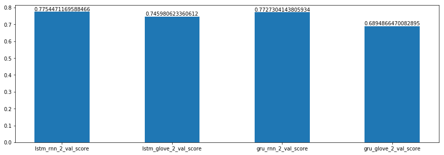

```python
import matplotlib.pyplot as plt
%matplotlib inline

labels = ['lstm_rnn_2_val_score','lstm_glove_2_val_score','gru_rnn_2_val_score','gru_glove_2_val_score']
scores = [lstm_rnn_2_val_score,lstm_glove_2_val_score,gru_rnn_2_val_score,gru_glove_2_val_score]
plt.figure(figsize=(15, 5))
plt.bar(labels, scores, width=0.5)
for i, score in enumerate(scores):
    plt.text(i, score, str(score),ha='center', va='bottom')
```

As we can see from the results, the best RNN model is lstm_rnn_2 which is the model adjusted based on LSTM (Trained From Scratch), then we add a second recurrent chain on the model.

```
Fold: 1
(7999, 50) (7999,)
Train on 7999 samples, validate on 2001 samples
Fold: 2
(7999, 50) (7999,)
Train on 7999 samples, validate on 2001 samples
Fold: 3
(8000, 50) (8000,)
Train on 8000 samples, validate on 2000 samples
Fold: 4
(8001, 50) (8001,)
Train on 8001 samples, validate on 1999 samples
Fold: 5
(8001, 50) (8001,)
Train on 8001 samples, validate on 1999 samples
_________________________________________________________________
Layer (type)                 Output Shape              Param #
=================================================================
input_30 (InputLayer)        (None, 50)                0
_________________________________________________________________
embedding_31 (Embedding)     (None, 50, 100)           1000000
_________________________________________________________________
lstm_34 (LSTM)               (None, 50, 50)            30200
_________________________________________________________________
lstm_35 (LSTM)               (None, 50)                20200
_________________________________________________________________
dense_50 (Dense)             (None, 1)                 51
=================================================================
Total params: 1,050,451
Trainable params: 1,050,451
Non-trainable params: 0
_________________________________________________________________
None
```

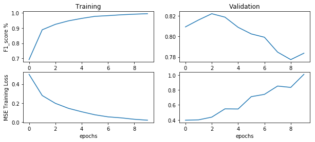

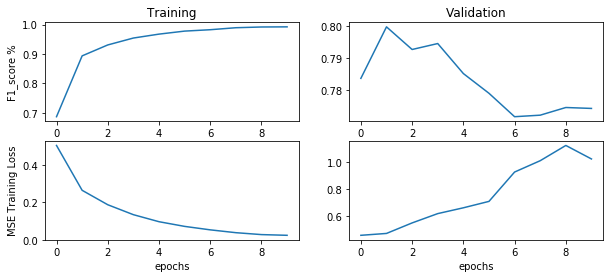

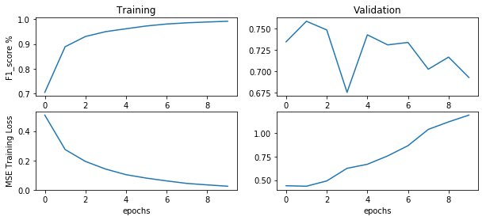

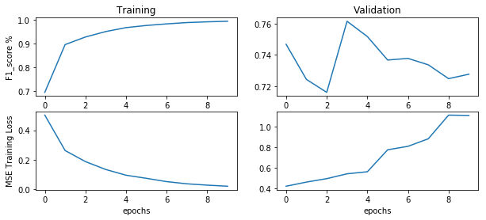

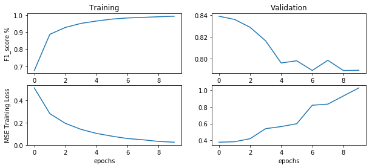

```python
top_words = 10000
max_review_length = 50
NUM_CLASSES = 1
EMBED_SIZE = 100
i = 0
score9 = []
val_score9 = []

for train_index, test_index in cv.split(X,y):
    i = i + 1
    print('Fold:', i)
    X_train, X_test = X[train_index], X[test_index]
    y_train, y_test = y[train_index], y[test_index]
    print(X_train.shape, y_train.shape)
    input_holder = Input(shape=(X_train.shape[1], ))
    shared_embed = Embedding(top_words, # input dimension (max int of OHE)
                             EMBED_SIZE, # output dimension size
                             input_length=max_review_length)(input_holder)

    x = LSTM(50, dropout=0.1, recurrent_dropout=0.1,return_sequences=True)(shared_embed)
    x = LSTM(50, dropout=0.1, recurrent_dropout=0.1)(x)
    x = Dense(NUM_CLASSES, activation='sigmoid')(x)
    lstm_rnn_3=Model(inputs=input_holder,outputs=x)
    lstm_rnn_3.compile(loss='binary_crossentropy',
                     optimizer='rmsprop',
                     metrics=[f1score])
    history9 = lstm_rnn_3.fit(X_train, y_train, epochs=10, batch_size=128, validation_data=(X_test, y_test))
    score = np.sum(history9.history['f1score'])/10
    val_score = np.sum(history9.history['val_f1score'])/10
    score9.append(score)
    val_score9.append(val_score)

    plt.figure(figsize=(10,4))
    plt.subplot(2,2,1)
    plt.plot(history9.history['f1score'])

    plt.ylabel('F1_score %')
    plt.title('Training')
    plt.subplot(2,2,2)
    plt.plot(history9.history['val_f1score'])
    plt.title('Validation')

    plt.subplot(2,2,3)
    plt.plot(history9.history['loss'])
    plt.ylabel('MSE Training Loss')
    plt.xlabel('epochs')

    plt.subplot(2,2,4)
    plt.plot(history9.history['val_loss'])
    plt.xlabel('epochs')

print(lstm_rnn_3.summary())
```

```python
for score in score9:
    print(score)
lstm_rnn_3_score = np.mean(np.array(score9))
print("average f1score:", lstm_rnn_3_score)

for score in val_score9:
    print(score)
lstm_rnn_3_val_score = np.mean(np.array(val_score9))
print("average val_f1score:", lstm_rnn_3_val_score)
```

```
0.9340255073024745
0.9366757663246513
0.93549930986166
0.9370816021975152
0.9330688692378842
average f1score: 0.935270210984837
0.8023114080014435
0.7828125075302619
0.7233783438682556
0.7361415764968238
0.8078906111057668
average val_f1score: 0.7705068894005103
```

Compare to the results of Adjusted LSTM (trained from scratch), we can get that the average f1score of model lstm_rnn_3 which adds a second recurrent chain is the best, it's 0.935, and the val_f1score almost the same.

## 2.4 Compare the Performance

In order to compare the performance of all 9 models, we decided to use histogram plot and Receiver operating characteristics and area under the curve (ROC & AUC) to do the comperation to determine which method is superior.

### Histogram

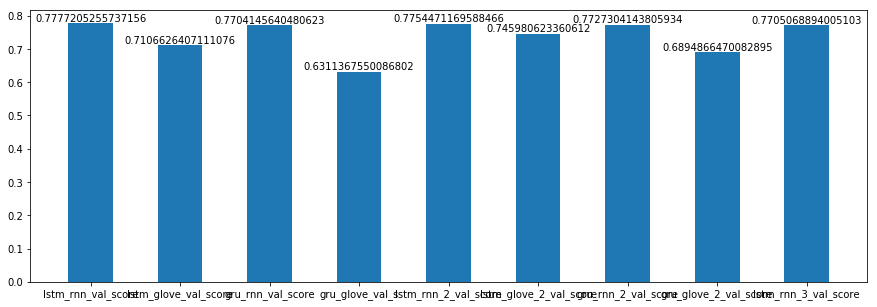

```python
labels = ['lstm_rnn_val_score','lstm_glove_val_score','gru_rnn_val_score','gru_glove_val_s',
          'lstm_rnn_2_val_score','lstm_glove_2_val_score','gru_rnn_2_val_score',
          'gru_glove_2_val_score','lstm_rnn_3_val_score']
scores = [lstm_rnn_val_score,lstm_glove_val_score,gru_rnn_val_score,gru_glove_val_score,
          lstm_rnn_2_val_score,lstm_glove_2_val_score,gru_rnn_2_val_score,
          gru_glove_2_val_score,lstm_rnn_3_val_score]
plt.figure(figsize=(15, 5))
plt.bar(labels, scores, width=0.5)
for i, score in enumerate(scores):
    plt.text(i, score, str(score),ha='center', va='bottom')
```

From the plot above, we can tell that from the average of val_f1score, lstm_rnn model, LSTM (trained from scratch), has the best result. The model gru_rnn, lstm_rnn_2, gru_rnn_2, lstm_rnn_3 all have the value which around 0.77, they are also good. And since our dataset is all about text, we are gonna to say that this val_f1score of model is acceptable.

### ROC

```python
from sklearn.metrics import roc_curve, auc
from scipy import interp
import matplotlib.pyplot as plt
%matplotlib inline

def plot_roc(model,model_name):
    cv = StratifiedKFold(n_splits=5)
    kfold = cv.split(X,y)

    mean_tpr = 0.0
    mean_fpr = np.linspace(0, 1, 100)
    all_tpr = []

    for i, (train, test) in enumerate(kfold):
        probas = model.predict(X[test])

        perclass_mean_tpr = 0.0
        roc_auc = 0
        classes = np.unique(y[train])
    # get the mean fpr and tpr, per class
        for j in classes:
            fpr, tpr, thresholds = roc_curve(y[test],
                                         probas)
            perclass_mean_tpr += interp(mean_fpr, fpr, tpr)
            perclass_mean_tpr[0] = 0.0
            roc_auc += auc(fpr, tpr)

        perclass_mean_tpr /= len(classes)
        roc_auc /= len(classes)
        mean_tpr += perclass_mean_tpr
        plt.plot(mean_fpr,perclass_mean_tpr,'--',lw=1,label='Mean Class ROC fold %d (area = %0.5f)'
                   % (i+1, roc_auc))

    mean_tpr /= 5
    mean_auc = auc(mean_fpr, mean_tpr)
    plt.plot(mean_fpr,perclass_mean_tpr,'k-',lw=2,label='Total Mean ROC (area = %0.5f)'
                   % (mean_auc))
    plt.legend(loc='best')
    plt.xlabel('false positive rate')
    plt.ylabel('true positive rate')
    plt.title('%s ROC Curve'%(model_name))
    plt.grid()


def plot_roc_2(model,model_name):
    cv = StratifiedKFold(n_splits=5)
    kfold = cv.split(X,y)

    mean_tpr = 0.0
    mean_fpr = np.linspace(0, 1, 100)
    all_tpr = []

    for i, (train, test) in enumerate(kfold):
        probas = model.predict(X[test])

        perclass_mean_tpr = 0.0
        roc_auc = 0
        classes = np.unique(y[train])
    # get the mean fpr and tpr, per class
        for j in classes:
            fpr, tpr, thresholds = roc_curve(y[test],
                                         probas[:, j],
                                         pos_label=j)
            perclass_mean_tpr += interp(mean_fpr, fpr, tpr)
            perclass_mean_tpr[0] = 0.0
            roc_auc += auc(fpr, tpr)

        perclass_mean_tpr /= len(classes)
        roc_auc /= len(classes)
        mean_tpr += perclass_mean_tpr
        plt.plot(mean_fpr,perclass_mean_tpr,'--',lw=1,label='Mean Class ROC fold %d (area = %0.5f)'
                   % (i+1,roc_auc))

    mean_tpr /= 5
    mean_auc = auc(mean_fpr, mean_tpr)
    plt.plot(mean_fpr,perclass_mean_tpr,'k-',lw=2,label='Total Mean ROC (area = %0.5f)'
                   % (mean_auc))
    plt.legend(loc='best')
    plt.xlabel('false positive rate')
    plt.ylabel('true positive rate')
    plt.title('%s ROC Curve'%(model_name))
    plt.grid()
```

```python
def compare_rnn(lstm_rnn, lstm_glove, gru_rnn, gru_glove,lstm_rnn_2, lstm_glove_2, gru_rnn_2, gru_glove_2, lstm_rnn_3):
    plt.figure(figsize=(15,5))
    plt.subplots_adjust(top=2,wspace = 0.2,hspace = 0.5)
    if lstm_rnn is not None:
        plt.subplot(5,2,1)
        plot_roc(lstm_rnn,'lstm_rnn')
    if lstm_glove is not None:
        plt.subplot(5,2,2)
        plot_roc_2(lstm_glove,'lstm_glove')
    if gru_rnn is not None:
        plt.subplot(5,2,3)
        plot_roc(gru_rnn,'gru_rnn')
    if gru_glove is not None:
        plt.subplot(5,2,4)
        plot_roc_2(gru_glove,'gru_glove')
    if lstm_rnn_2 is not None:
        plt.subplot(5,2,5)
        plot_roc(lstm_rnn_2,'lstm_rnn_2')
    if lstm_glove_2 is not None:
        plt.subplot(5,2,6)
        plot_roc_2(lstm_glove_2,'lstm_glove_2')
    if gru_rnn_2 is not None:
        plt.subplot(5,2,7)
        plot_roc(gru_rnn_2,'gru_rnn_2')
    if gru_glove_2 is not None:
        plt.subplot(5,2,8)
        plot_roc_2(gru_glove_2,'gru_glove_2')
    if lstm_rnn_3 is not None:
        plt.subplot(5,2,9)
        plot_roc(lstm_rnn_3,'lstm_rnn_3')
```

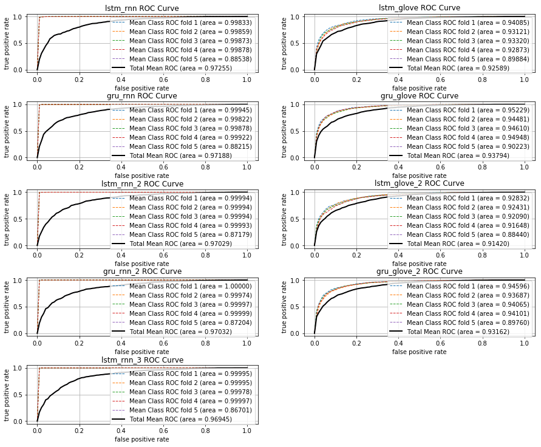

```python
compare_rnn(lstm_rnn, lstm_glove, gru_rnn, gru_glove,lstm_rnn_2, lstm_glove_2, gru_rnn_2, gru_glove_2, lstm_rnn_3)
```

From the two different comparation method above, we can get the same answer that LSTM (trained from scratch) model has the best performance for our dataset.

# 3. Exception work

Our team choose to participate research study,and we all made appointment with Elena. Here are emails for each team members:

-Xiangying Chang (xiangyingc@smu.edu) made an appointment at May 16th.  
-Rui Lin (ruil@smu.edu) made an appointment at May 14th.  
-Fang Qi (fangq@smu.edu) already done on May 9th.  
-Shimeng Yuan (shimengy@smu.edu) made an appointment at May 28th.

# Reference:

1. https://www.kaggle.com/anshulrai/cudnnlstm-implementation-93-7-accuracy
2. https://github.com/eclarson/MachineLearningNotebooks/blob/master/13.%20RNN%20Basics.ipynb